# Week 8 - Homework

STAT 420, Summer 2018, apoorva6

## Exercise 1 (Writing Functions)

**(a)** Write a function named `diagnostics` that takes as input the arguments:

- `model`, an object of class `lm()`, that is a model fit via `lm()`
- `pcol`, for controlling point colors in plots, with a default value of `grey`
- `lcol`, for controlling line colors in plots, with a default value of `dodgerblue`
- `alpha`, the significance level of any test that will be performed inside the function, with a default value of `0.05`
- `plotit`, a logical value for controlling display of plots with default value `TRUE`
- `testit`, a logical value for controlling outputting the results of tests with default value `TRUE`

The function will output:

- A list with two elements when `testit` is `TRUE`:
  - `p_val`, the p-value for the Shapiro-Wilk test for assessing normality
  - `decision`, the decision made when performing the Shapiro-Wilk test using the `alpha` value input to the function. “Reject” if the null hypothesis is rejected, otherwise “Fail to Reject.”
- Two plots, side-by-side, when `plotit` is `TRUE`:
  - A fitted versus residuals plot that adds a horizontal line at $y = 0$, and labels the $x$-axis “Fitted” and the $y$-axis “Residuals.” The points and line should be colored according to the input arguments. Give the plot a title.
  - A Normal Q-Q plot of the residuals that adds the appropriate line using `qqline()`. The points and line should be colored according to the input arguments. Be sure the plot has a title.

```r
diagnostics <- function(model, pcol="grey",lcol="dodgerblue",alpha=0.05,plotit=TRUE,testit=TRUE)
{
    p_val <- shapiro.test(resid(model))$p.value
    decision <- ifelse(p_val < alpha, "Reject H0-Suspect Normality","Fail to reject H0-Normality assumption not suspected")
    if(plotit == TRUE)
    {
     par(mfrow = c(1, 2))
     plot(fitted(model), resid(model), col = pcol, pch = 20,
          xlab = "Fitted", ylab = "Residuals", main = "Fitted versus Residuals Plot")
     abline(h = 0, col = lcol, lwd = 2)

     qqnorm(resid(model), main = "Normal Q-Q Plot, fit_1", col = pcol)
     qqline(resid(model), col = lcol, lwd = 2)
    }
 if( testit == TRUE)
 {
    return(list(p_val = p_val,decision = decision))
 }
}
```

**(b)** Run the following code.

```r
set.seed(420)

data_1 = data.frame(x = runif(n = 30, min = 0, max = 10),
                    y = rep(x = 0, times = 30))
data_1$y = with(data_1, 2 + 1 * x + rexp(n = 30))
fit_1 = lm(y ~ x, data = data_1)

data_2 = data.frame(x = runif(n = 20, min = 0, max = 10),
                    y = rep(x = 0, times = 20))
data_2$y = with(data_2, 5 + 2 * x + rnorm(n = 20))
fit_2 = lm(y ~ x, data = data_2)

data_3 = data.frame(x = runif(n = 40, min = 0, max = 10),
                    y = rep(x = 0, times = 40))
data_3$y = with(data_3, 2 + 1 * x + rnorm(n = 40, sd = x))
fit_3 = lm(y ~ x, data = data_3)
```

```r
diagnostics(fit_1, plotit = FALSE)$p_val
```

```
## [1] 0.0004299
```

```r
diagnostics(fit_2, plotit = FALSE)$decision
```

```
## [1] "Fail to reject H0-Normality assumption not suspected"
```

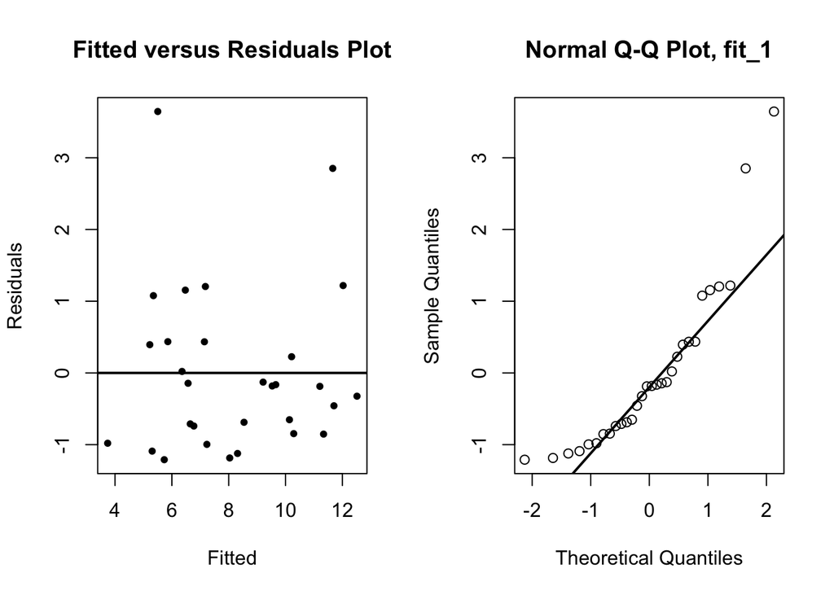

```r
diagnostics(fit_1, testit = FALSE, pcol = "black", lcol = "black")
```

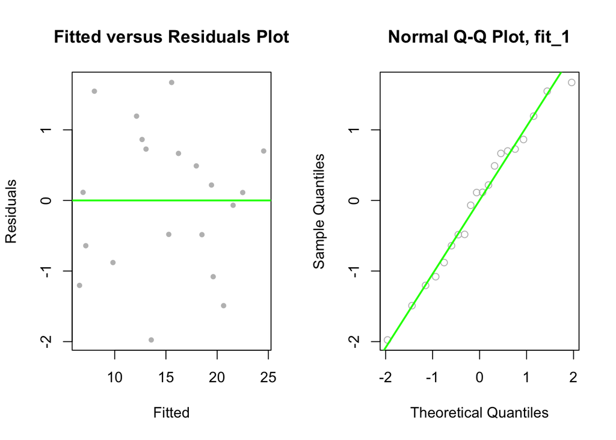

```r
diagnostics(fit_2, testit = FALSE, pcol = "grey", lcol = "green")
```

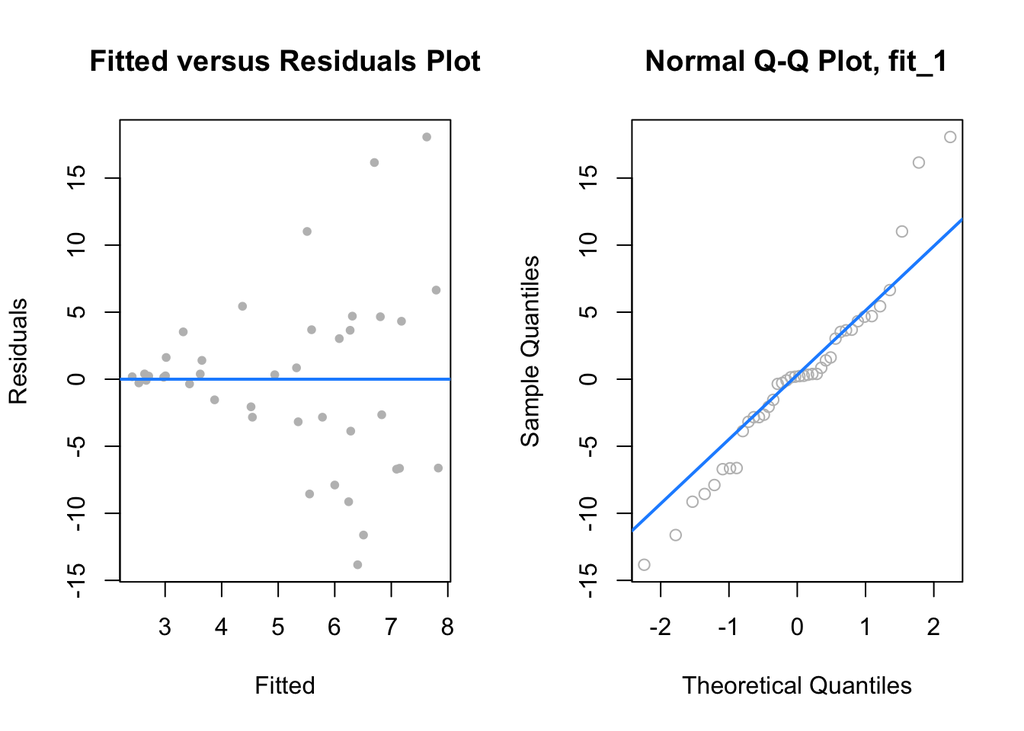

```
## $p_val
## [1] 0.09105
##
## $decision
## [1] "Fail to reject H0-Normality assumption not suspected"
```

```r
diagnostics(fit_3)
```

## Exercise 2 (Prostate Cancer Data)

For this exercise, we will use the `prostate` data, which can be found in the `faraway` package. After loading the `faraway` package, use `?prostate` to learn about this dataset.

```r
library(faraway)
```

**(a)** Fit an additive multiple regression model with `lpsa` as the response and the remaining variables in the `prostate` dataset as predictors. Report the $R^2$ value for this model.

```r
additive <- lm(lpsa ~ ., data = prostate)
summary(additive)$r.squared
```

```
## [1] 0.6548
```

**(b)** Check the constant variance assumption for this model. Do you feel it has been violated? Justify your answer.

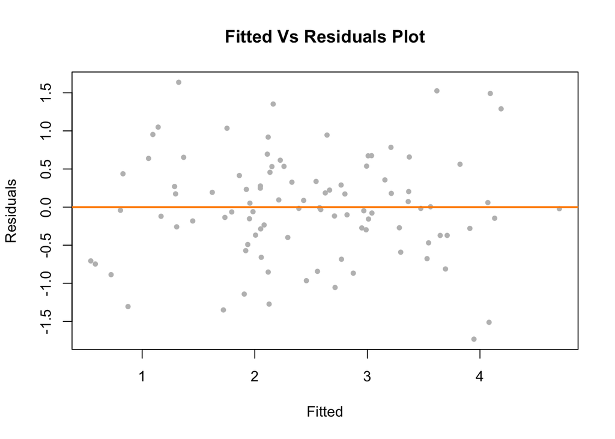

```r
#Fitted Vs residuals plot
plot(fitted(additive), resid(additive), col = "grey", pch = 20,
     xlab = "Fitted", ylab = "Residuals", main = "Fitted Vs Residuals Plot")
abline(h = 0, col = "darkorange", lwd = 2)
```

```r
#BP test
library(lmtest)
bptest(additive)
```

```
##
##  studentized Breusch-Pagan test
##
## data:  additive
## BP = 10, df = 8, p-value = 0.3
```

```
- There is no violation of assumption of equal variance. This is tested in the following ways:
- From the Fitted Vs Residuals plot, we can see that the variance of residuals across its fitted values almost remains the same.
- This can be further proven through the Breusch-Pagan Test, where the p values is high; which fails to reject the H0 that the data has constant variance
```

**(c)** Check the normality assumption for this model. Do you feel it has been violated? Justify your answer.

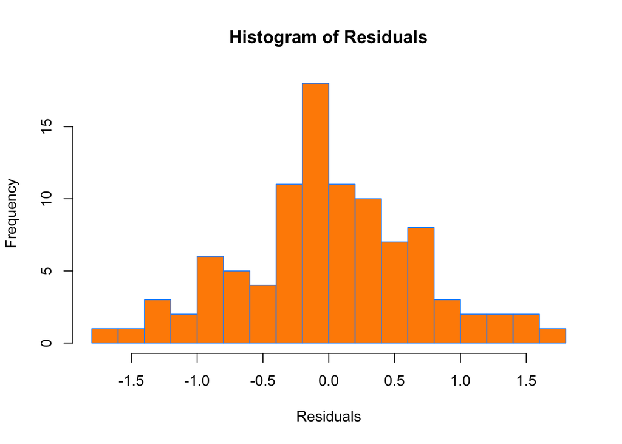

```r
#Histogram of residuals
hist(resid(additive),
     xlab   = "Residuals",
     main   = "Histogram of Residuals",
     col    = "darkorange",
     border = "dodgerblue",
     breaks = 20)
```

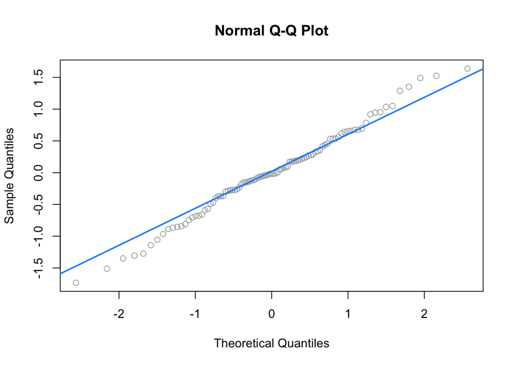

```r
#Q-Q plot
qqnorm(resid(additive), main = "Normal Q-Q Plot", col = "darkgrey")
qqline(resid(additive), col = "dodgerblue", lwd = 2)
```

```r
#Shapiro-Wilk Test
shapiro.test(resid(additive))
```

```
##
##  Shapiro-Wilk normality test
##
## data:  resid(additive)
## W = 0.99, p-value = 0.8
```

```
- There is no violation of assumption of normality. This is tested in three ways:
- First, we plot a histogram to study the shape of the residuals of the model. The plot almost looks like a normal distribution.
- Second we build a Q-Q Plot using the residuals. Here too the datapoints closely follow a straight line with very little deviations in the tails.
- Lastly, we perform a Shapiro-Wilk Test, which shows a high P-value. Thus we fail to reject the H0 that the data follows a normal distribution.
```

**(d)** Check for any high leverage observations. Report any observations you determine to have high leverage.

```r
hatvalues(additive)[hatvalues(additive) > 2 * mean(hatvalues(additive))]
```

```
##     32     37     41     74     92
## 0.3305 0.2184 0.2410 0.1912 0.2092
```

**(e)** Check for any influential observations. Report any observations you determine to be influential.

```r
influential <- cooks.distance(additive)
influential_points <- influential[influential > 4 / length(influential)]
influential_points
```

```
##      32      39      47      69      95      96      97
## 0.12270 0.05202 0.10574 0.10054 0.09874 0.05594 0.07378
```

**(f)** Refit the additive multiple regression model without any points you identified as influential. Compare the coefficients of this fitted model to the previously fitted model.

```r
additive_fix = lm(lpsa ~ ., data = prostate,
                    subset = influential <= 4 / length(influential))
coef(additive_fix)
```

```
## (Intercept)      lcavol     lweight         age        lbph         svi
##    -0.24608     0.56499     0.54443    -0.01856     0.13328     0.74475
##         lcp     gleason       pgg45
##    -0.15542     0.11472     0.00665
```

```r
coef(additive)
```

```
## (Intercept)      lcavol     lweight         age        lbph         svi
##    0.669337    0.587022    0.454467   -0.019637    0.107054    0.766157
##         lcp     gleason       pgg45
##   -0.105474    0.045142    0.004525
```

[output not shown]

**(g)** Create a data frame that stores the observations that were “removed” because they were influential. Use the two models you have fit to make predictions with these observations. Comment on the difference between these two sets of predictions.

```r
new_data <- prostate[as.numeric(names(influential_points)),1:8]

 predict(additive,newdata= new_data)
```

```
##    32    39    47    69    95    96    97
## 2.875 3.947 4.081 1.325 3.618 4.188 4.092
```

```r
 predict(additive_fix,newdata= new_data)
```

```
##    32    39    47    69    95    96    97
## 3.106 3.898 4.284 1.340 3.327 4.220 3.905
```

[output not shown]

## Exercise 3 (Why Bother?)

**Why** do we care about violations of assumptions? One key reason is that the distributions of the parameter esimators that we have used are all reliant on these assumptions. When the assumptions are violated, the distributional results are not correct, so our tests are garbage. **Garbage In, Garbage Out!**

Consider the following setup that we will use for the remainder of the exercise. We choose a sample size of 50.

```r
n = 50
set.seed(420)
x_1 = runif(n, 0, 5)
x_2 = runif(n, -2, 2)
```

Consider the model,

$$Y = 4 + 1 x_1 + 0 x_2 + \epsilon.$$

That is,

- $\beta_0$ = 4
- $\beta_1$ = 1
- $\beta_2$ = 0

We now simulate `y_1` in a manner that does **not** violate any assumptions, which we will verify. In this case $\epsilon \sim N(0, 1).$. We also simulate `y_2` in a manner that **does** violate assumptions, which we again verify. In this case $\epsilon \sim N(0, \sigma = |x_2|).$

**(a)** Repeat the process of generating `y_1` and `y_2` as defined above, and fit models with each as the response `2500` times. Each time, store the p-value for testing,

$$\beta_2 = 0,$$

using both models, in the appropriate variables defined above.

```r
num_sims = 2500
p_val_1 = rep(0, num_sims)
p_val_2 = rep(0, num_sims)
birthday = 19920720
set.seed(birthday)


for ( i in 1:num_sims)
{

  y_1 = 4 + 1 * x_1 + 0 * x_2 + rnorm(n = n, mean = 0, sd = 1)
  fit_1 = lm(y_1 ~ x_1 + x_2)
  # qqnorm(resid(fit_1), col = "grey", pch = 20)
  # qqline(resid(fit_1), col = "dodgerblue", lwd = 2)
  # grid()
  p_val_1[i] <- summary(fit_1)$coefficients[3,4]
  y_2 = 4 + 1 * x_1 + 0 * x_2  + rnorm(n = n, mean = 0, sd = abs(x_2))
  fit_2 = lm(y_2 ~ x_1 + x_2)
  # qqnorm(resid(fit_2), col = "grey", pch = 20)
  # qqline(resid(fit_2), col = "dodgerblue", lwd = 2)
  # grid()
  p_val_2[i] <- summary(fit_2)$coefficients[3,4]
}
```

**(b)** What proportion of the `p_val_1` values is less than 0.01? Less than 0.05? Less than 0.10? What proportion of the `p_val_2` values is less than 0.01? Less than 0.05? Less than 0.10? Arrange your results in a table. Briefly explain these results.

```r
p_val_1_0.01 <- length(which(p_val_1 < 0.01)) / length(p_val_1)
p_val_1_0.05 <- length(which(p_val_1 < 0.05)) / length(p_val_1)
p_val_1_0.10 <- length(which(p_val_1 < 0.10)) / length(p_val_1)


p_val_2_0.01 <- length(which(p_val_2 < 0.01)) / length(p_val_2)
p_val_2_0.05 <- length(which(p_val_2 < 0.05)) / length(p_val_2)
p_val_2_0.10 <- length(which(p_val_2 < 0.10)) / length(p_val_2)

p_value_1 <- c(p_val_1_0.01,p_val_1_0.05,p_val_1_0.10)
p_value_2 <- c(p_val_2_0.01,p_val_2_0.05,p_val_2_0.10)

pvalues <- data.frame(p_value_1,p_value_2)
rownames(pvalues) <- c("0.01","0.05","0.10")
library(knitr)
kable(pvalues, format = "markdown")
```

|  | p_value_1 | p_value_2 |
| --- | --- | --- |
| 0.01 | 0.0128 | 0.0372 |
| 0.05 | 0.0588 | 0.1172 |
| 0.10 | 0.0992 | 0.1852 |

[output not shown]

## Exercise 4 (Corrosion Data)

For this exercise, we will use the `corrosion` data, which can be found in the `faraway` package.

```r
library(faraway)
```

**(a)** Fit a simple linear regression with `loss` as the response and `Fe` as the predictor. Plot a scatterplot and add the fitted line. Check the assumptions of this model.

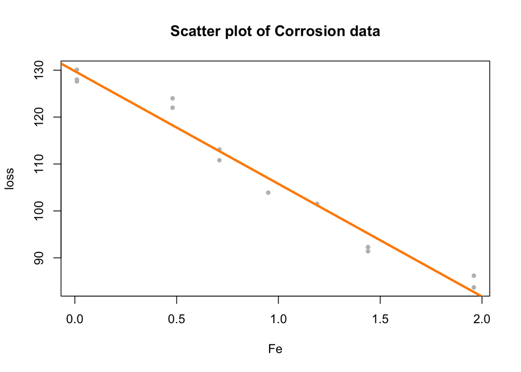

```r
model <- lm(loss~Fe, data=corrosion)
plot(loss~Fe, data=corrosion, col = "grey", pch = 20,
     main = "Scatter plot of Corrosion data")
abline(model, col = "darkorange", lwd = 3)
```

**Check the assumptions of this model.**

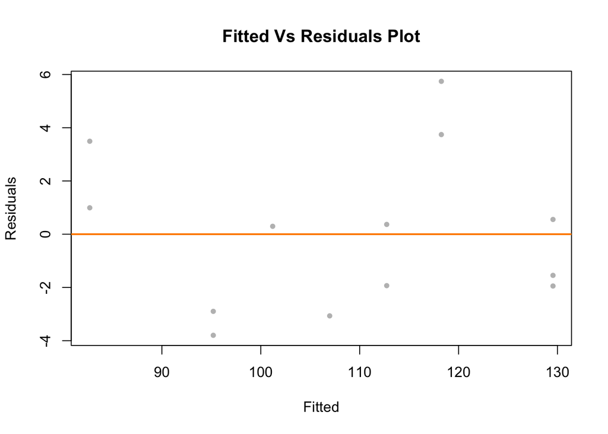

```r
# Constant variance assumption
plot(fitted(model), resid(model), col = "grey", pch = 20,
     xlab = "Fitted", ylab = "Residuals", main = "Fitted Vs Residuals Plot")
abline(h = 0, col = "darkorange", lwd = 2)
```

```r
library(lmtest)
bptest(model)
```

```
##
##  studentized Breusch-Pagan test
##
## data:  model
## BP = 0.025, df = 1, p-value = 0.9
```

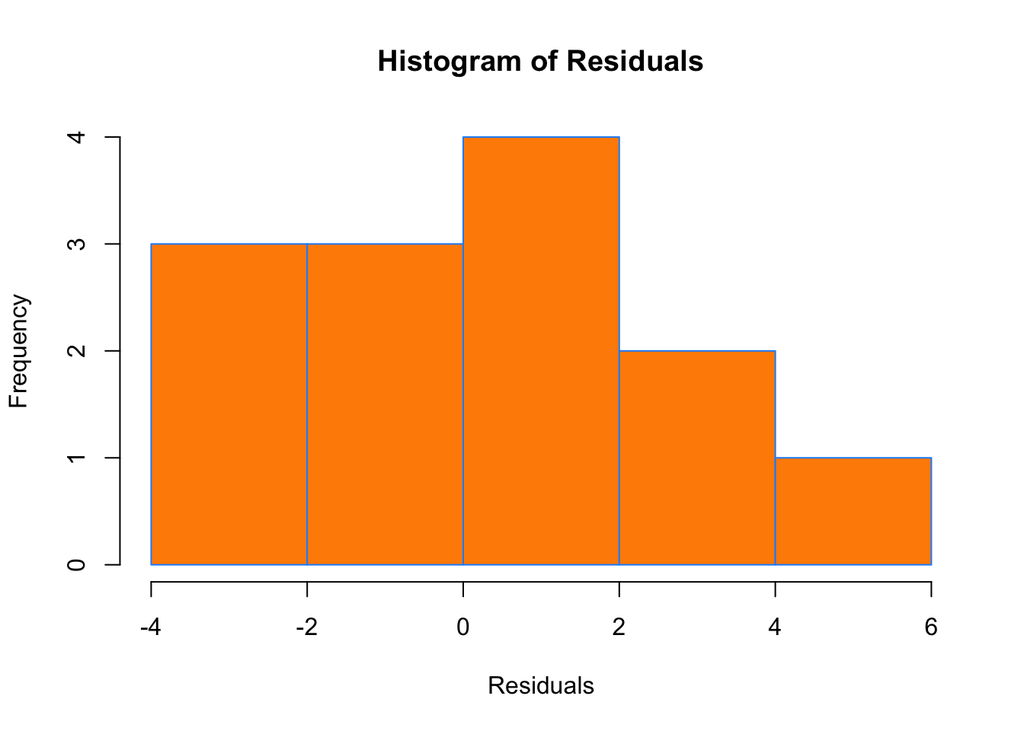

```r
#Normality assumption
hist(resid(model),
     xlab   = "Residuals",
     main   = "Histogram of Residuals",
     col    = "darkorange",
     border = "dodgerblue")
```

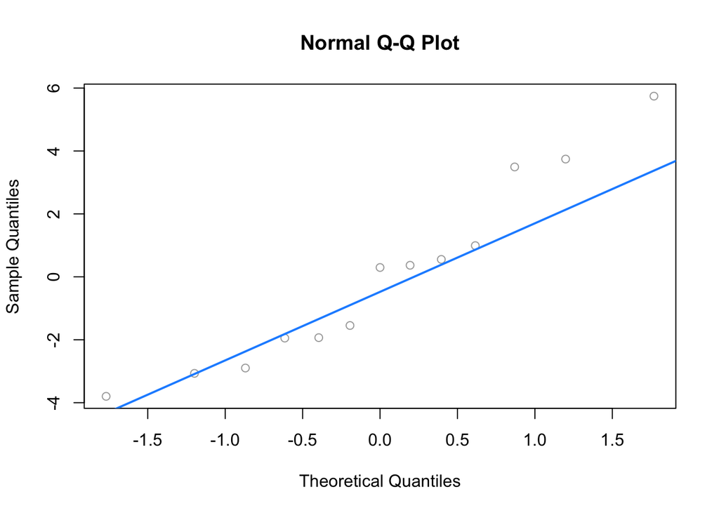

```r
qqnorm(resid(model), main = "Normal Q-Q Plot", col = "darkgrey")
qqline(resid(model), col = "dodgerblue", lwd = 2)
```

```r
shapiro.test(resid(model))
```

```
##
##  Shapiro-Wilk normality test
##
## data:  resid(model)
## W = 0.93, p-value = 0.4
```

[output not shown]

**(b)** Fit higher order polynomial models of degree 2, 3, and 4. For each, plot a fitted versus residuals plot and comment on the constant variance assumption. Based on those plots, which of these three models do you think are acceptable? Use a statistical test(s) to compare the models you just chose. Based on the test, which is preferred? Check the normality assumption of this model. Identify any influential observations of this model.

```r
model_2degree <- lm(loss~Fe+ I(Fe ^ 2), data=corrosion)
model_3degree <- lm(loss~Fe+ I(Fe ^ 2)+I(Fe ^ 3), data=corrosion)
model_4degree <-  lm(loss~Fe+ I(Fe ^ 2)+ I(Fe ^ 3)+I(Fe ^ 4), data=corrosion)
```

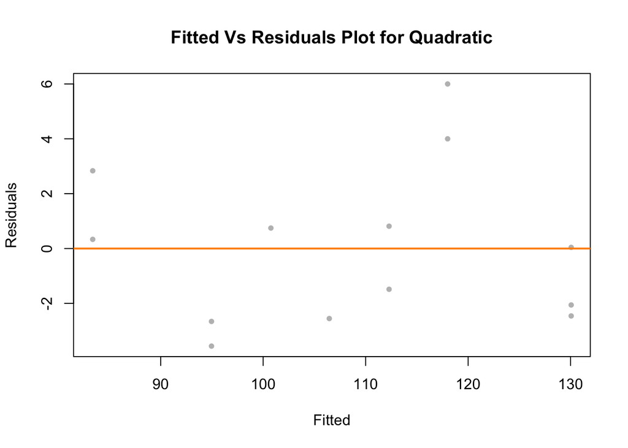

```r
plot(fitted(model_2degree), resid(model_2degree), col = "grey", pch = 20,
     xlab = "Fitted", ylab = "Residuals", main = "Fitted Vs Residuals Plot for Quadratic")
abline(h = 0, col = "darkorange", lwd = 2)
```

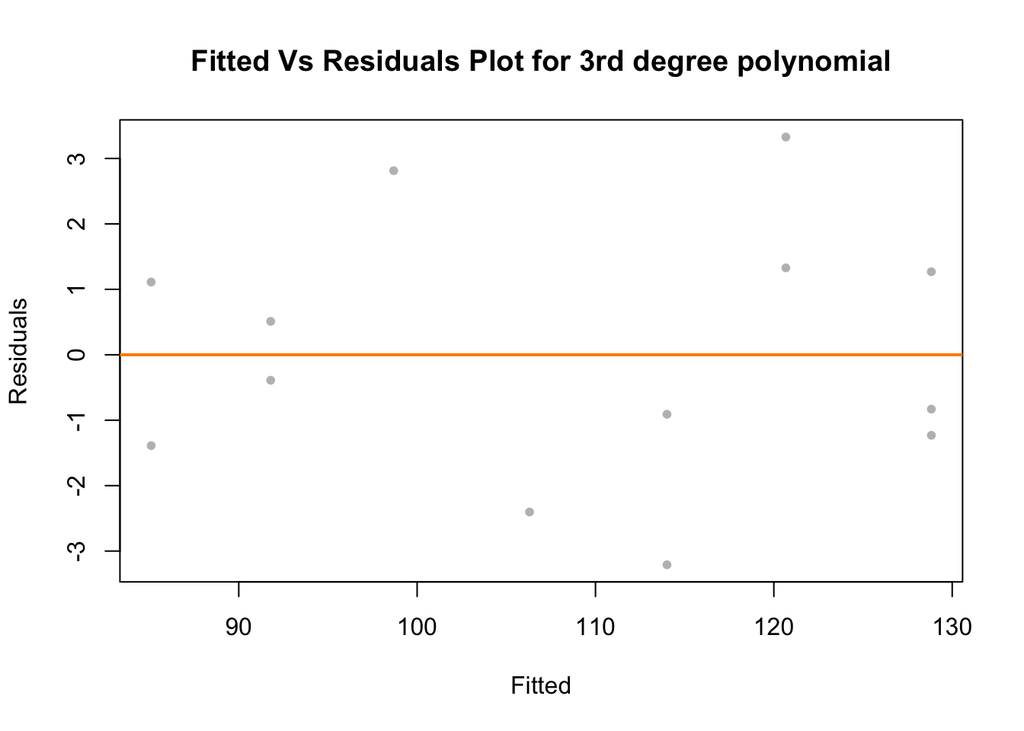

```r
plot(fitted(model_3degree), resid(model_3degree), col = "grey", pch = 20,
     xlab = "Fitted", ylab = "Residuals", main = "Fitted Vs Residuals Plot for 3rd degree polynomial")
abline(h = 0, col = "darkorange", lwd = 2)
```

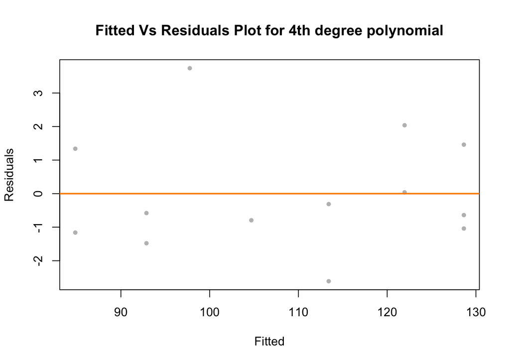

[output not shown]

```r
plot(fitted(model_4degree), resid(model_4degree), col = "grey", pch = 20,
     xlab = "Fitted", ylab = "Residuals", main = "Fitted Vs Residuals Plot for 4th degree polynomial")
abline(h = 0, col = "darkorange", lwd = 2)
```

From the graph it might be evident that the quadratic model is better. We will further study this using the BP-test. Here we consider the all 3 models

```r
library(lmtest)
bptest(model_2degree)
```

```
##
##  studentized Breusch-Pagan test
##
## data:  model_2degree
## BP = 0.78, df = 2, p-value = 0.7
```

```r
bptest(model_3degree)
```

```
##
##  studentized Breusch-Pagan test
##
## data:  model_3degree
## BP = 4.8, df = 3, p-value = 0.2
```

```r
bptest(model_4degree)
```

```
##
##  studentized Breusch-Pagan test
##
## data:  model_4degree
## BP = 2.7, df = 4, p-value = 0.6
```

```
 - From the BP-test it is clear that the quadratic model is the better one because of its higher P value than the 4th degree polynomial model.
```

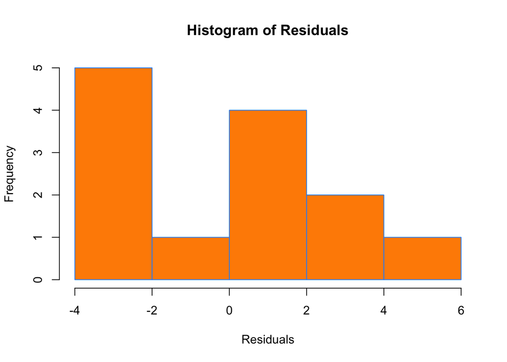

```r
#Normality assumption
hist(resid(model_2degree),
     xlab   = "Residuals",
     main   = "Histogram of Residuals",
     col    = "darkorange",
     border = "dodgerblue")
```

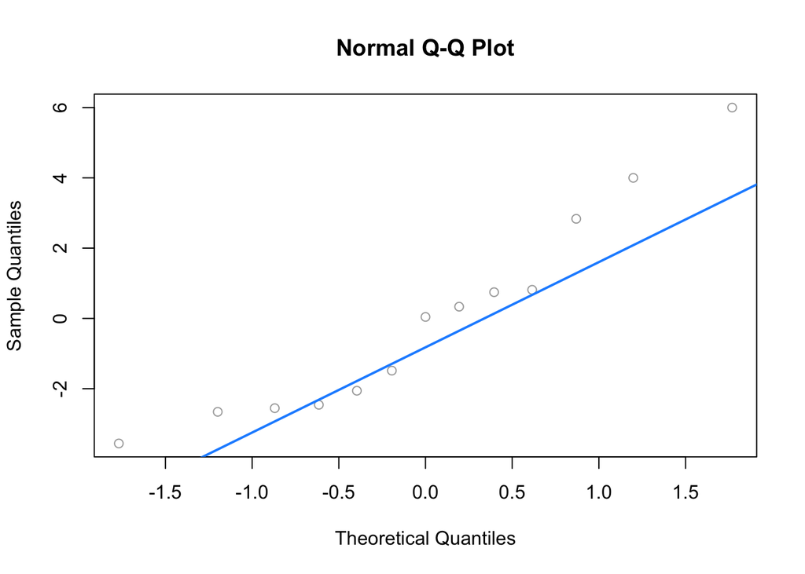

```r
qqnorm(resid(model_2degree), main = "Normal Q-Q Plot", col = "darkgrey")
qqline(resid(model_2degree), col = "dodgerblue", lwd = 2)
```

```r
shapiro.test(resid(model_2degree))
```

```
##
##  Shapiro-Wilk normality test
##
## data:  resid(model_2degree)
## W = 0.92, p-value = 0.3
```

```r
influential <- cooks.distance(model_2degree)
influential_points <- influential[influential > 4 / length(influential)]
influential_points
```

```
##     13
## 0.3767
```

## Exercise 5 (Diamonds)

The data set `diamonds` from the `ggplot2` package contains prices and characteristics of 54,000 diamonds. For this exercise, use `price` as the response variable $y$, and `carat` as the predictor $x$. Use `?diamonds` to learn more.

```r
library(ggplot2)
```

**(a)** Fit a linear model with `price` as the response variable $y$, and `carat` as the predictor $x$. Return the summary information of this model.

```r
diamonds_model <- lm(price ~ carat,data= diamonds)
summary(diamonds_model)
```

```
##
## Call:
## lm(formula = price ~ carat, data = diamonds)
##
## Residuals:
##    Min     1Q Median     3Q    Max
## -18585   -805    -19    537  12732
##
## Coefficients:
##             Estimate Std. Error t value Pr(>|t|)
## (Intercept)  -2256.4       13.1    -173   <2e-16 ***
## carat         7756.4       14.1     551   <2e-16 ***
## ---
## Signif. codes:  0 '***' 0.001 '**' 0.01 '*' 0.05 '.' 0.1 ' ' 1
##
## Residual standard error: 1550 on 53938 degrees of freedom
## Multiple R-squared:  0.849,  Adjusted R-squared:  0.849
## F-statistic: 3.04e+05 on 1 and 53938 DF,  p-value: <2e-16
```

**(b)** Plot a scatterplot of price versus carat and add the line for the fitted model in part **(a)**. Using a fitted versus residuals plot and/or a Q-Q plot, comment on the diagnostics.

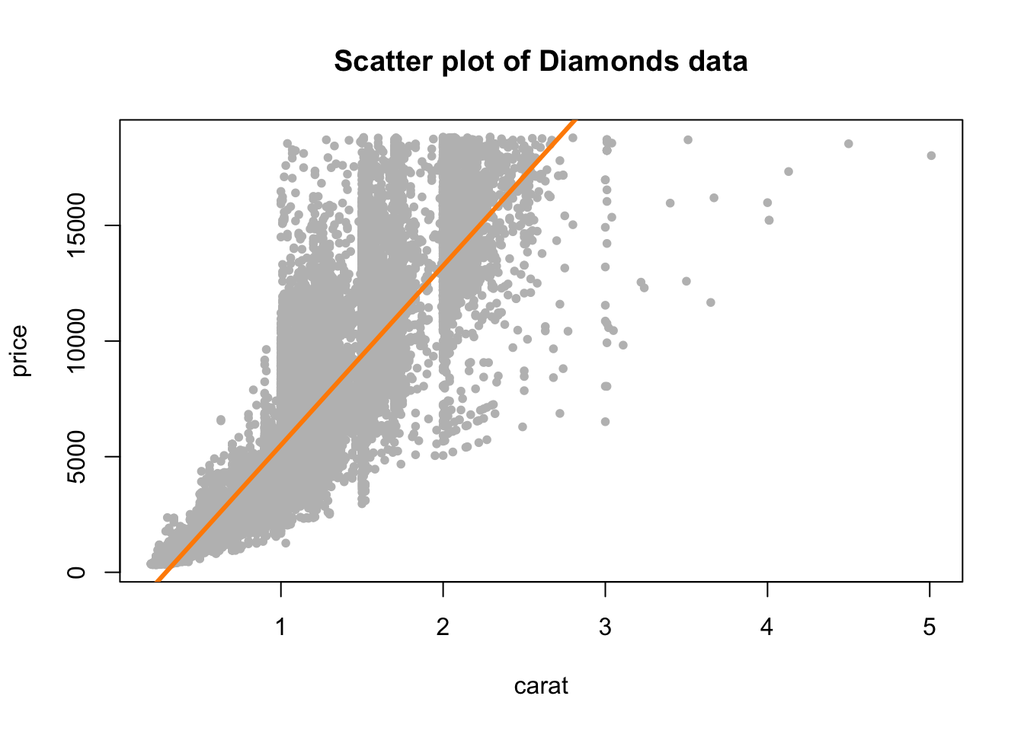

```r
plot(price ~ carat, data = diamonds, col = "grey", pch = 20,
     main = "Scatter plot of Diamonds data")
abline(diamonds_model, col = "darkorange", lwd = 3)
```

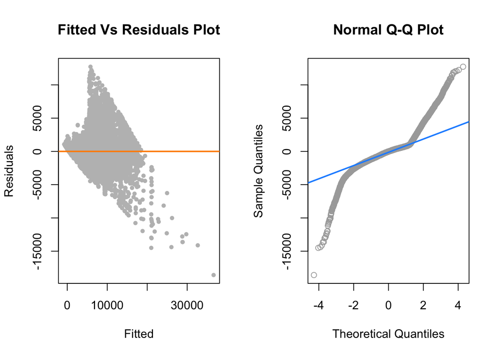

```
- From the Fitted Vs residuals plot, it is clear that the data does not have equal variance. Also, the data is not linear.
- The Q-Q plot shows a lot of deviations in the tails. This could be more of a t-distribution than a normal distribution.
Thus the data violates all the assumptions of a linear regression model.
```

```r
#Fitted Vs residuals plot
par(mfrow = c(1, 2))
plot(fitted(diamonds_model), resid(diamonds_model), col = "grey", pch = 20,
     xlab = "Fitted", ylab = "Residuals", main = "Fitted Vs Residuals Plot")
abline(h = 0, col = "darkorange", lwd = 2)

#Normality plot
qqnorm(resid(diamonds_model), main = "Normal Q-Q Plot", col = "darkgrey")
qqline(resid(diamonds_model), col = "dodgerblue", lwd = 2)
```

**(c)** Seeing as the price stretches over several orders of magnitude, it seems reasonable to try a log transformation of the response. Fit a model with a logged response, plot a scatterplot of log-price versus carat and add the line for the fitted model, then use a fitted versus residuals plot and/or a Q-Q plot to comment on the diagnostics of the model.

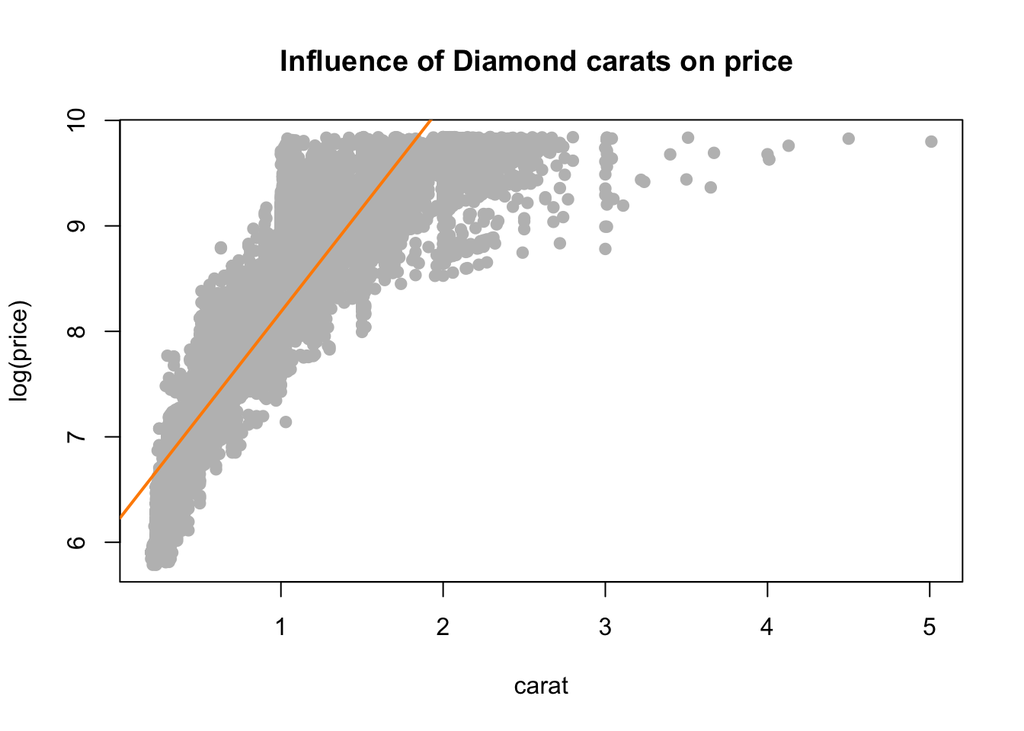

```r
diamonds_model_log <- lm(log(price) ~ carat,data= diamonds)
plot(log(price) ~ carat,data= diamonds, col = "grey", pch = 20, cex = 1.5,
     main = "Influence of Diamond carats on price ")
abline(diamonds_model_log, col = "darkorange", lwd = 2)
```

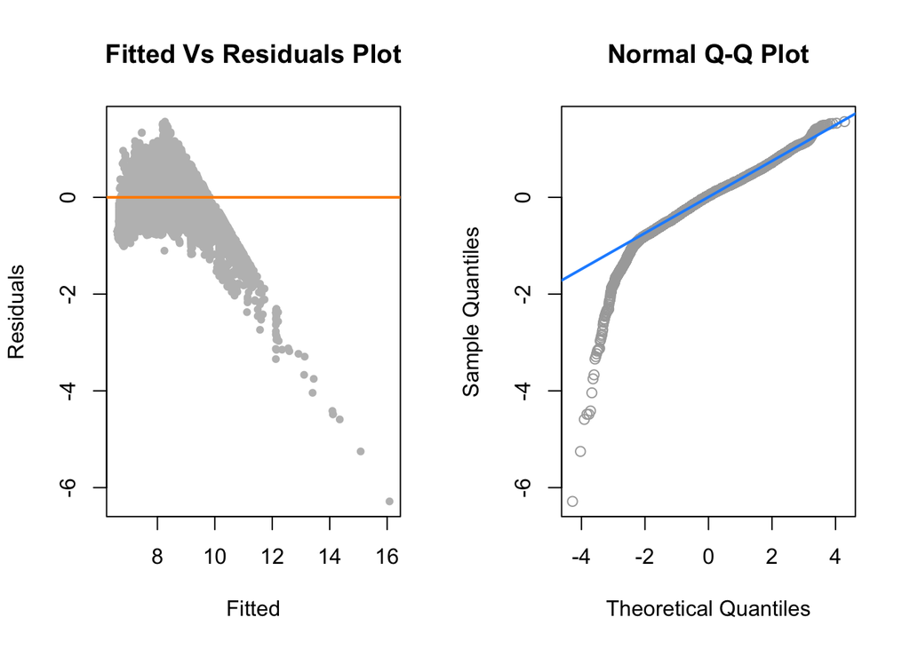

```
- The concept of equal variance in the Fitted Vs residuals plot looks better than the model without log transformation.
- The Q-Q plot also shows a better fit to the blue line on the top end.
 Thus, this transformation does not completely relieve the model from its violation of assumptions, but performs much better than the first model.
```

```r
#Fitted Vs residuals plot
par(mfrow = c(1, 2))
plot(fitted(diamonds_model_log), resid(diamonds_model_log), col = "grey", pch = 20,
     xlab = "Fitted", ylab = "Residuals", main = "Fitted Vs Residuals Plot")
abline(h = 0, col = "darkorange", lwd = 2)

#Normality plot
qqnorm(resid(diamonds_model_log), main = "Normal Q-Q Plot", col = "darkgrey")
qqline(resid(diamonds_model_log), col = "dodgerblue", lwd = 2)
```

**(d)** Try adding log transformation of the predictor. Fit a model with a logged response and logged predictor, plot a scatterplot of log-price versus log-carat and add the line for the fitted model, then use a fitted versus residuals plot and/or a Q-Q plot to comment on the diagnostics of the model.

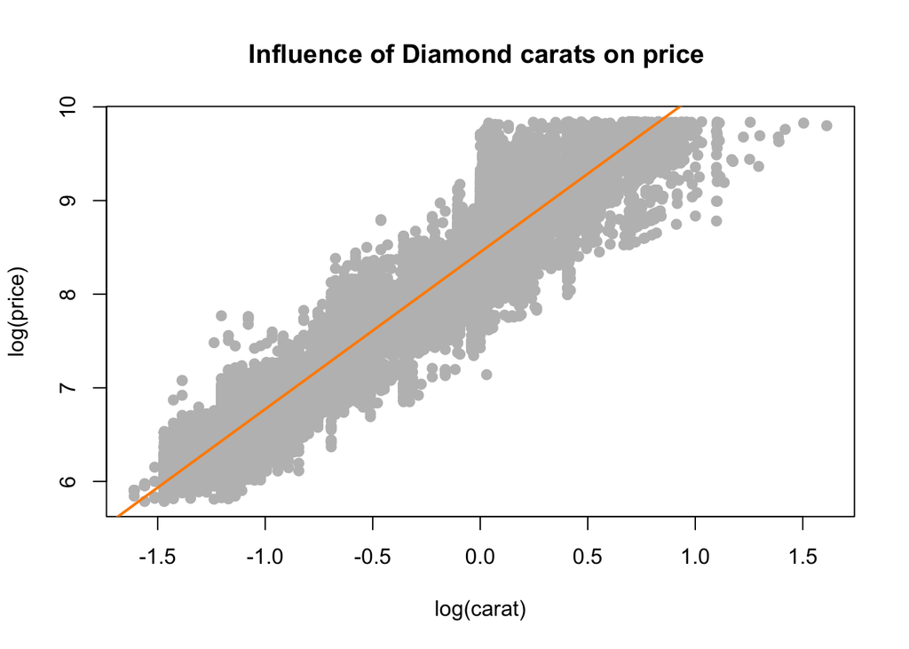

```r
diamonds_model_log1 <- lm(log(price) ~ log(carat),data= diamonds)
plot(log(price) ~ log(carat),data= diamonds, col = "grey", pch = 20, cex = 1.5,
     main = "Influence of Diamond carats on price ")
abline(diamonds_model_log1, col = "darkorange", lwd = 2)
```

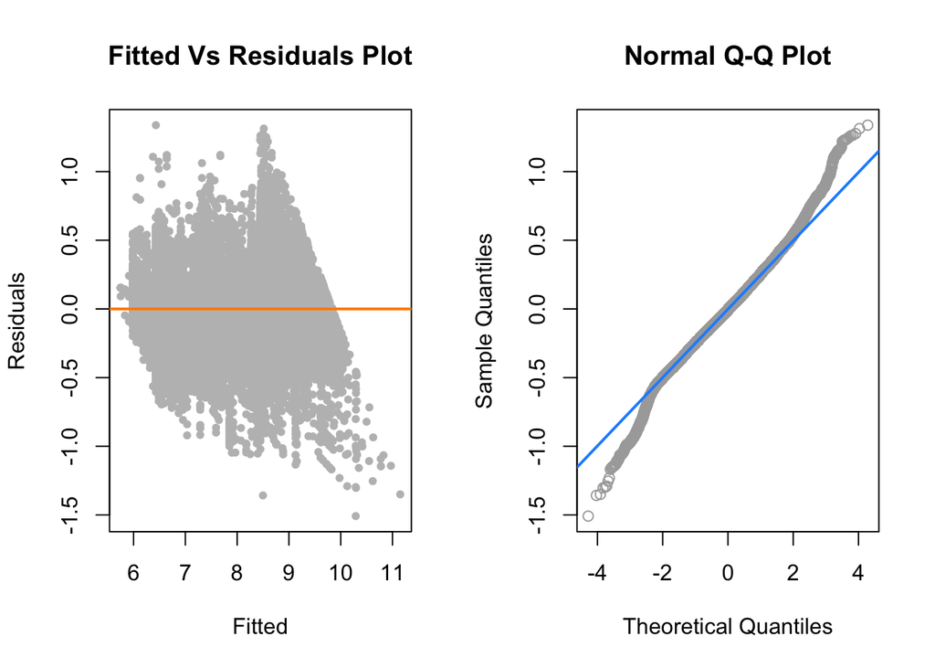

[output not shown]

```r
#Fitted Vs residuals plot
par(mfrow = c(1, 2))
plot(fitted(diamonds_model_log1), resid(diamonds_model_log1), col = "grey", pch = 20,
     xlab = "Fitted", ylab = "Residuals", main = "Fitted Vs Residuals Plot")
abline(h = 0, col = "darkorange", lwd = 2)

#Normality plot
qqnorm(resid(diamonds_model_log1), main = "Normal Q-Q Plot", col = "darkgrey")
qqline(resid(diamonds_model_log1), col = "dodgerblue", lwd = 2)
```

**(e)** Use the model from part **(d)** to predict the price (in dollars) of a 3-carat diamond. Construct a 99% prediction interval for the price (in dollars).

```r
exp(predict(diamonds_model_log1, newdata = data.frame(carat=c(log(3))), interval = "prediction", level = 0.99))
```

```
##    fit  lwr   upr
## 1 5466 2779 10752
```